# Unemployment over Time

A DIIG introduction to reproducible computational analysis and report writing

John Little

2021-02-08

**R, RStudio, and the Tidyverse** are three components of a modern computational environment that leverages important characteristics of data science. This tool suite is extensible but accessible to researchers working at various levels of complexity. This example report demonstrates how computational analysis can be supported by a *reproducible workflow*. You will see how RStudio and the Tidyverse are geared to support *reproducibility*; can render reports in various formats; affords convenient functions to support the vital and time-consuming tasks of *data wrangling* (80% of any data project); can be used to produce sophisticated *visualizations*; and leverages cutting-edge *data management* techniques and workflows.

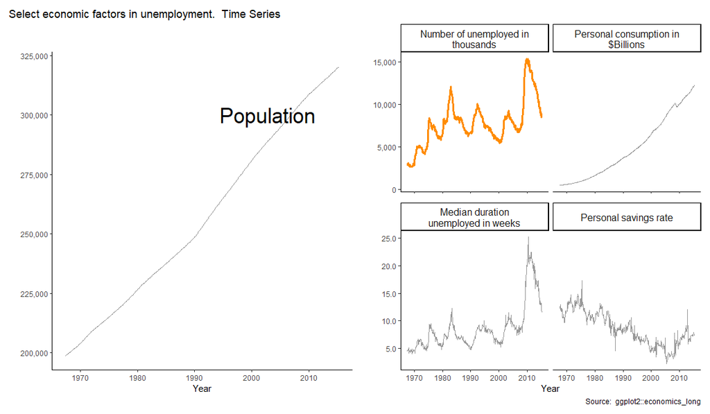

## Explanation

This report was generated by leveraging various [Tidyverse](https://tidyverse.org) packages listed, and briefly introduced, below.

## dplyr

https://dplyr.tidyverse.org

Subset and sort

- `filter()` rows [observations]
- `select()` columns [variables]
- `arrange()` arrange rows by a variable

New variables and column totals

- `mutate()` create a new variable
- `summarize()` column totals
- `group_by()` when used with summarize, column subtotals

Add data from other data frames

- `left_join()`
- `anti_join()`

## tidyr

https://tidyr.tidyverse.org

- `pivot_longer()`
- `pivot_wider()`

## Visualization (**ggplot2**) & EDA

https://ggplot2.tidyverse.org https://docs.ropensci.org/skimr

- `skimr::skim()` - a good place to start for Exploratory Data Analysis
- `geom_histogram()`
- `geom_bar()` (and `geom_col()`)
- `geom_boxplot()`
- `geom_line()` (time series)
- `geom_point()`

## Resources

https://github.com/libjohn/presentation_dii

- [This code repository](https://github.com/libjohn/presentation_diig)
- [Videos and guides](https://rfun.library.duke.edu/portfolio/r_flipped/)
- [Tidyverse documentation](https://tidyverse.org)
- [Center for Data & Visualization Sciences](https://library.duke.edu/data)

## License

https://JohnLittle.info  
[CC BY-NC](https://creativecommons.org/licenses/by-nc/4.0/)  
Creative Commons: Attribution, Non Commercial